# R Notebook

| area | year | measurement | units | value | region_of_residence | breakdown_of_domestic_tourism |
| --- | --- | --- | --- | --- | --- | --- |
| West Dunbartonshire | 2016-2018 | Count | million pounds (GBP) | 8 | England | Expenditure |
| West Dunbartonshire | 2015-2017 | Count | Thousand Nights | 140 | All of GB | Nights |
| West Dunbartonshire | 2015-2017 | Count | million pounds (GBP) | 8 | England | Expenditure |
| West Dunbartonshire | 2017-2019 | Count | Thousand Nights | 76 | England | Nights |
| West Dunbartonshire | 2009-2011 | Count | Thousand Visits | 68 | Scotland | Visits |
| West Dunbartonshire | 2016-2018 | Count | Thousand Nights | 59 | Scotland | Nights |
| West Dunbartonshire | 2016-2018 | Count | million pounds (GBP) | 4 | Scotland | Expenditure |
| West Dunbartonshire | 2013-2015 | Count | Thousand Visits | 32 | Scotland | Visits |
| West Dunbartonshire | 2012-2014 | Count | million pounds (GBP) | 6 | England | Expenditure |
| West Dunbartonshire | 2015-2017 | Count | Thousand Visits | 28 | England | Visits |

[output cut: 990 more lines]

| area | year | measurement | units | value | accommodation_type_and_occupancy | weekday_weekend | size_of_accommodation | location |
| --- | --- | --- | --- | --- | --- | --- | --- | --- |
| Scotland | 2012 | Percent | Percentage | 52.32 | Guest House/B&B - Room Occupancy | All | All | Accessible Small Towns |
| Scotland | 2015 | Percent | Percentage | 49.18 | Guest House/B&B - Room Occupancy | All | All | Large Urban Areas |
| Scotland | 2018 | Percent | Percentage | 63.57 | Guest House/B&B - Room Occupancy | All | All | Large Urban Areas |
| Scotland | 2013 | Percent | Percentage | 53.35 | Guest House/B&B - Room Occupancy | All | All | Accessible Rural |
| Scotland | 2018 | Percent | Percentage | 40.45 | Guest House/B&B - Room Occupancy | All | All | Accessible Rural |
| Scotland | 2019 | Percent | Percentage | 43.93 | Guest House/B&B - Room Occupancy | All | All | Accessible Small Towns |
| Scotland | 2016 | Percent | Percentage | 38.76 | Guest House/B&B - Room Occupancy | All | Rooms: 01-03 | All |
| Scotland | 2017 | Percent | Percentage | 60.24 | Guest House/B&B - Room Occupancy | All | All | Other Urban Areas |
| Scotland | 2016 | Percent | Percentage | 45.44 | Guest House/B&B - Room Occupancy | All | All | Other Urban Areas |
| Scotland | 2015 | Percent | Percentage | 46.54 | Guest House/B&B - Room Occupancy | All | All | Remote Rural |

[output cut: 701 more lines]

| area | year | measurement | units | value | tourism_activity | breakdown_of_domestic_tourism |
| --- | --- | --- | --- | --- | --- | --- |
| Scotland | 2019 | Count | million pounds (GBP) | 1662 | Shopping for items that you do not regularly buy | Expenditure |
| Scotland | 2016 | Count | million pounds (GBP) | 469 | Watched live sporting events (not on TV) | Expenditure |
| Scotland | 2014 | Count | million pounds (GBP) | 892 | Night out to a bar, pub and/or club | Expenditure |
| Scotland | 2017 | Count | million pounds (GBP) | 354 | Special personal events e.g. wedding, graduation | Expenditure |
| Scotland | 2015 | Count | million pounds (GBP) | 400 | Watched live sporting events (not on TV) | Expenditure |
| Scotland | 2014 | Count | million pounds (GBP) | 421 | Watched live sporting events (not on TV) | Expenditure |
| Scotland | 2013 | Count | million pounds (GBP) | 243 | Watched live sporting events (not on TV) | Expenditure |
| Scotland | 2015 | Count | million pounds (GBP) | 264 | Leisure activities e.g. hobbies & evening classes | Expenditure |
| Scotland | 2018 | Count | million pounds (GBP) | 285 | Leisure activities e.g. hobbies & evening classes | Expenditure |
| Scotland | 2014 | Count | million pounds (GBP) | 1536 | Shopping for items that you do not regularly buy | Expenditure |

[output cut: 214 more lines]

| area | year | measurement | units | value | breakdown_of_domestic_tourism | age | marital_status | gender | employment_status | children | access_to_car | social_grade |
| --- | --- | --- | --- | --- | --- | --- | --- | --- | --- | --- | --- | --- |
| Scotland | 2013 | Count | Million Visits | 22 | Visits | 45-54 years | All | All | All | All | All | All |
| Scotland | 2013 | Count | Million Visits | 58 | Visits | All | All | Male | All | All | All | All |
| Scotland | 2016 | Count | Million Visits | 23 | Visits | 25-34 years | All | All | All | All | All | All |
| Scotland | 2019 | Count | Million Visits | 56 | Visits | All | Not Married | All | All | All | All | All |
| Scotland | 2015 | Count | Million Visits | 52 | Visits | All | Not Married | All | All | All | All | All |
| Scotland | 2015 | Count | Million Visits | 15 | Visits | 45-54 years | All | All | All | All | All | All |
| Scotland | 2018 | Count | Million Visits | 23 | Visits | 65 years and over | All | All | All | All | All | All |
| Scotland | 2018 | Count | Million Visits | 59 | Visits | All | Not Married | All | All | All | All | All |
| Scotland | 2014 | Count | Million Visits | 73 | Visits | All | Married | All | All | All | All | All |
| Scotland | 2016 | Count | Million Visits | 142 | Visits | All | All | All | All | All | All | All |

[output cut: 298 more lines]

| area | year | measurement | units | value | type_of_location_visited | breakdown_of_domestic_tourism |
| --- | --- | --- | --- | --- | --- | --- |
| Scotland | 2014 | Count | million pounds (GBP) | 186 | Seaside - beach | Expenditure |
| Scotland | 2019 | Count | million pounds (GBP) | 1456 | Small town | Expenditure |
| Scotland | 2016 | Count | million pounds (GBP) | 4916 | All areas | Expenditure |
| Scotland | 2018 | Count | million pounds (GBP) | 5474 | All areas | Expenditure |
| Scotland | 2013 | Count | million pounds (GBP) | 217 | Seaside - beach | Expenditure |
| Scotland | 2018 | Count | million pounds (GBP) | 6 | Seaside - other | Expenditure |
| Scotland | 2018 | Count | million pounds (GBP) | 1234 | Small town | Expenditure |
| Scotland | 2015 | Count | million pounds (GBP) | 230 | Seaside resort or town | Expenditure |
| Scotland | 2016 | Count | million pounds (GBP) | 302 | Seaside resort or town | Expenditure |
| Scotland | 2019 | Count | million pounds (GBP) | 359 | Seaside resort or town | Expenditure |

[output cut: 102 more lines]

| area | year | measurement | units | value | method_of_travel | breakdown_of_domestic_tourism |
| --- | --- | --- | --- | --- | --- | --- |
| Scotland | 2018 | Count | million pounds (GBP) | 251.8 | Walked | Expenditure |
| Scotland | 2018 | Count | million pounds (GBP) | 1.8 | Caravan/Campervan | Expenditure |
| Scotland | 2014 | Count | million pounds (GBP) | 97.8 | Walked | Expenditure |
| Scotland | 2017 | Count | million pounds (GBP) | 168.8 | Walked | Expenditure |
| Scotland | 2018 | Count | million pounds (GBP) | 193.1 | Plane | Expenditure |
| Scotland | 2015 | Count | million pounds (GBP) | 89.4 | Plane | Expenditure |
| Scotland | 2013 | Count | million pounds (GBP) | 36.7 | Plane | Expenditure |
| Scotland | 2016 | Count | million pounds (GBP) | 8.3 | Plane | Expenditure |
| Scotland | 2019 | Count | million pounds (GBP) | 205.8 | Walked | Expenditure |
| Scotland | 2014 | Count | million pounds (GBP) | 21.8 | Boat/Ship/Ferry | Expenditure |

[output cut: 226 more lines]

Q8 *How have general tourism rates changed over time?* *OCCUPANCY* Change over the years, different size of the occupancy by its type

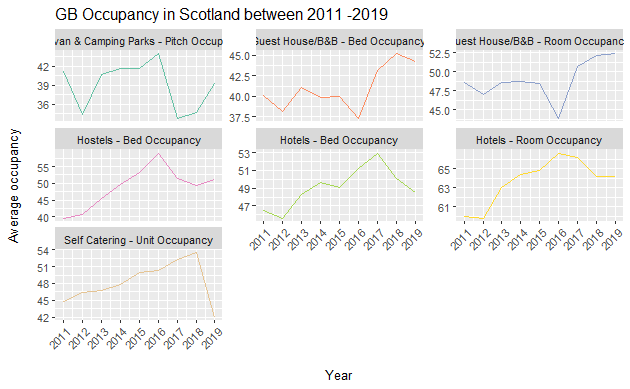

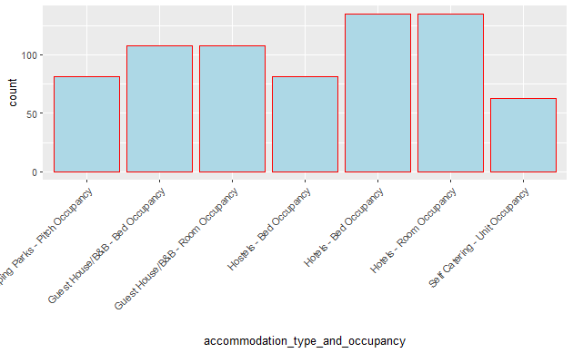

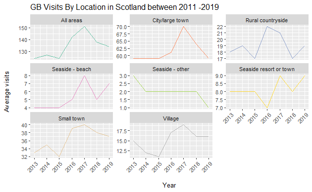

*DEMOGRAPHICS* By age, each year is different, for 2019 the data show that mostly all the age groups falland the only two that grow significantly , 65 or older and 35-44 years old , are under the mark of their beat year that was 2016.

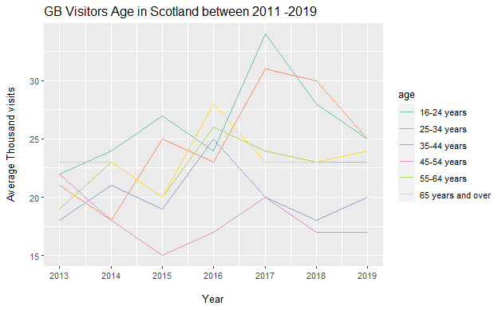

*TRANSPORT*

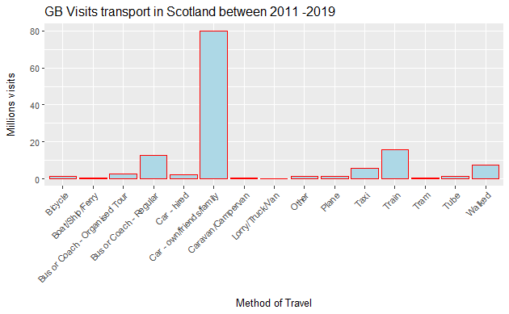

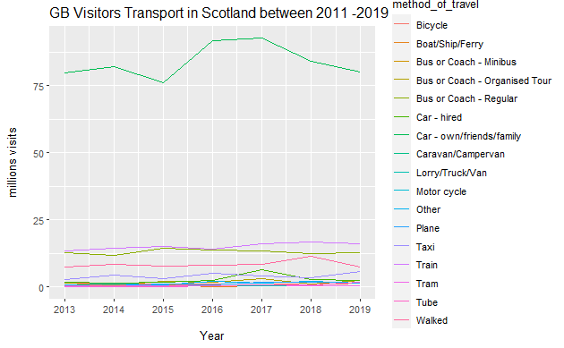

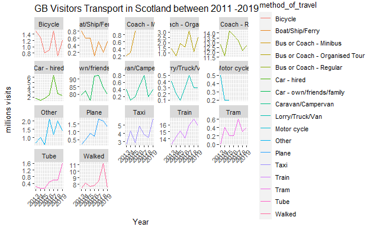

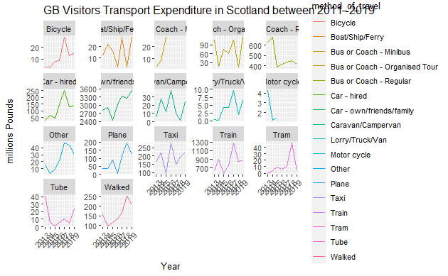

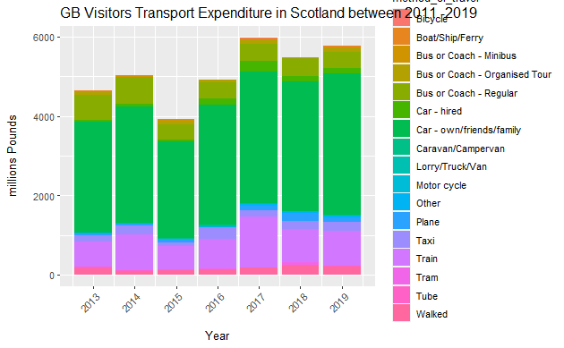

Q9

Spending/ Visits

| area | year | measurement | units | value | tourism_activity | breakdown_of_domestic_tourism |
| --- | --- | --- | --- | --- | --- | --- |
| Scotland | 2019 | Count | million pounds (GBP) | 1662 | Shopping for items that you do not regularly buy | Expenditure |
| Scotland | 2016 | Count | million pounds (GBP) | 469 | Watched live sporting events (not on TV) | Expenditure |
| Scotland | 2014 | Count | million pounds (GBP) | 892 | Night out to a bar, pub and/or club | Expenditure |
| Scotland | 2017 | Count | million pounds (GBP) | 354 | Special personal events e.g. wedding, graduation | Expenditure |
| Scotland | 2015 | Count | million pounds (GBP) | 400 | Watched live sporting events (not on TV) | Expenditure |
| Scotland | 2014 | Count | million pounds (GBP) | 421 | Watched live sporting events (not on TV) | Expenditure |
| Scotland | 2013 | Count | million pounds (GBP) | 243 | Watched live sporting events (not on TV) | Expenditure |
| Scotland | 2015 | Count | million pounds (GBP) | 264 | Leisure activities e.g. hobbies & evening classes | Expenditure |
| Scotland | 2018 | Count | million pounds (GBP) | 285 | Leisure activities e.g. hobbies & evening classes | Expenditure |
| Scotland | 2014 | Count | million pounds (GBP) | 1536 | Shopping for items that you do not regularly buy | Expenditure |

[output cut: 214 more lines]

| area | year | measurement | units | value | tourism_activity | breakdown_of_domestic_tourism |
| --- | --- | --- | --- | --- | --- | --- |
| Scotland | 2019 | Count | million pounds (GBP) | 1662 | Shopping for items that you do not regularly buy | Expenditure |
| Scotland | 2016 | Count | million pounds (GBP) | 469 | Watched live sporting events (not on TV) | Expenditure |
| Scotland | 2014 | Count | million pounds (GBP) | 892 | Night out to a bar, pub and/or club | Expenditure |
| Scotland | 2017 | Count | million pounds (GBP) | 354 | Special personal events e.g. wedding, graduation | Expenditure |
| Scotland | 2015 | Count | million pounds (GBP) | 400 | Watched live sporting events (not on TV) | Expenditure |
| Scotland | 2014 | Count | million pounds (GBP) | 421 | Watched live sporting events (not on TV) | Expenditure |
| Scotland | 2013 | Count | million pounds (GBP) | 243 | Watched live sporting events (not on TV) | Expenditure |
| Scotland | 2015 | Count | million pounds (GBP) | 264 | Leisure activities e.g. hobbies & evening classes | Expenditure |
| Scotland | 2018 | Count | million pounds (GBP) | 285 | Leisure activities e.g. hobbies & evening classes | Expenditure |
| Scotland | 2014 | Count | million pounds (GBP) | 1536 | Shopping for items that you do not regularly buy | Expenditure |

[output cut: 214 more lines]

My year is not a date is number Should I change to date? NO necessary. How to change my tibble to a tsibble for prediction

| year | breakdown_of_domestic_tourism | tourism_activity | value |
| --- | --- | --- | --- |
| 2013 | Expenditure | All | 4647 |
| 2014 | Expenditure | All | 5020 |
| 2015 | Expenditure | All | 3922 |
| 2016 | Expenditure | All | 4916 |
| 2017 | Expenditure | All | 5995 |
| 2018 | Expenditure | All | 5474 |
| 2019 | Expenditure | All | 5777 |
| 2013 | Expenditure | Day out to a beauty/health centre/spa, etc. | 145 |
| 2014 | Expenditure | Day out to a beauty/health centre/spa, etc. | 71 |
| 2015 | Expenditure | Day out to a beauty/health centre/spa, etc. | 87 |

[output cut: 102 more lines]

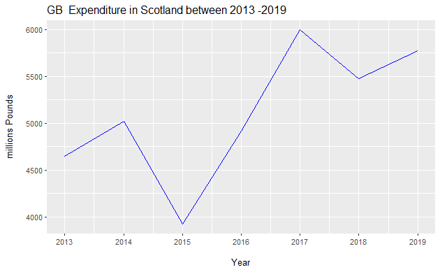

predict_visits.

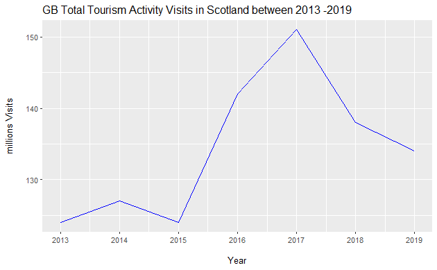

There were a peak in 2017 in visits to tourism_activity and expenditure, after there are a decrease in total number of visits but a decrease in expenditure. That could means an increase of price of the activities, less offer?. Less tourism but more money or visitors with more/ higher purchasing power

Q7

Try to do a grouped barchart Group barchart by ocupation type

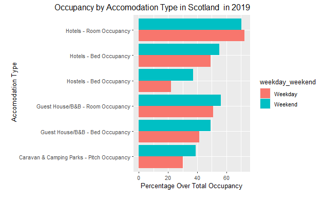

Cheap travels for long weekends. Note: difference Room and Bed occupancy, no clear but I understand that Room means the number of occupants per room but Bed means the number of occupants in a room per size bed = 1 single bed and 1 double bed means 3 max occupants

Group barchart by total occupation period time

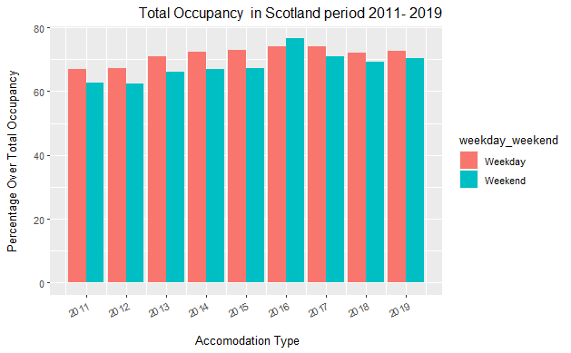

```
   _MORE SHIT_
```

Prediction - Not enough data to do a prediction.

| tourism_activity | .model | year | predict_spend | .mean |
| --- | --- | --- | --- | --- |
| All | snaive | 2020 |  | NA |
| All | snaive | 2021 |  | NA |
| All | snaive | 2022 |  | NA |
| All | snaive | 2023 |  | NA |
| All | snaive | 2024 |  | NA |
| All | snaive | 2025 |  | NA |
| All | snaive | 2026 |  | NA |
| All | snaive | 2027 |  | NA |
| All | snaive | 2028 |  | NA |
| All | snaive | 2029 |  | NA |

[output cut: 566 more lines]

Subseries- No work. Not enough data

Rolling Window -Impossible not enough data

*Extension* Decission Tree Age-Expenditure Doenst work because you need 10 thousand rows/ observations

# Train/test split